# lab 5

Eli Schulman

10/25/2021

### Overview of Setup and Setting Changes

- settings > Output Options >
  - table of contents: includes links to the RMarkdown sections (based on number of #’s)
  - changed theme to cerulean
  - code_folding: enables collapsible code in the RMarkdown

### Lab Overview - Confidence Intervals

```r
knitr::opts_chunk$set(echo = TRUE, message = FALSE, warning = FALSE)

library(tidyverse)
library(effsize)
```

## Part 1: use ‘t.test()’ to calculate confidence intervals

### Example 1:

- single mock sample
- in-line code referencing
- t.test()

```r
# create mock sample
otter_len <- c(30, 40, 55, 27, 38, 36, 39, 60, 69, 17)

# find confidence interval
otter_ci <- t.test(otter_len)

# find sd
otter_sd <- sd(otter_len)

# interpreting confidence interval of (28,50): if we took a bunch of samples, we'd expect that 95% of them would contain the sample mean between 28 and 50.
```

#### use in-line reference to draw from the t.test() numbers. use which makes the values in the text active

Mean otter length is 41.1 inches with a 95% confidence interval of [29.73, 52.47] inches.

### Example 2:

- create mock sample and decide whether we can reject the null hypothesis (default null hypothesis is: these samples were drawn from populations with the same mean) (null hypotheses –> difference in means of population is equal to 0)
- p.val of .15 and means of 5 and 7 –> if these samples were taken from pops with the same mean, theres a 15% chance that the difference in means would be 2 (7-5).
- reject null hypothesis if p.val < .05

#### Two sample t-test

```r
oak_trees <- c(20, 19, 23, 25, 21, 16)
pine_trees <- c(30, 22, 27, 23, 35, 32)

tree_t_test <- t.test(oak_trees, pine_trees)
```

## Part 2: t-test with cars and mpg

### look at data

```r
compact_suv <- mpg %>%
  filter(class %in% c('compact', 'suv'))

unique(compact_suv$class)
```

```
## [1] "compact" "suv"
```

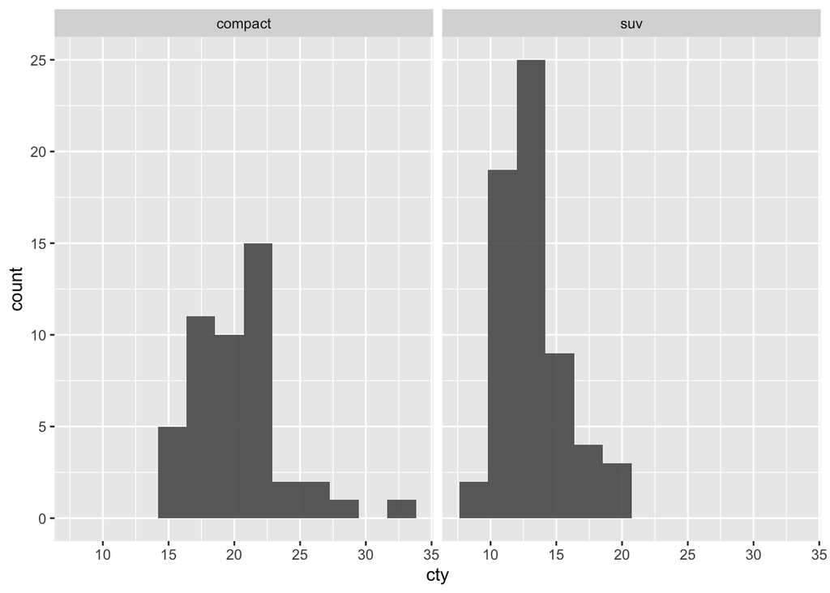

```r
ggplot(compact_suv, aes(x = cty)) +
  geom_histogram(alpha = .9, bins = 12) +
  facet_wrap(~ class)
```

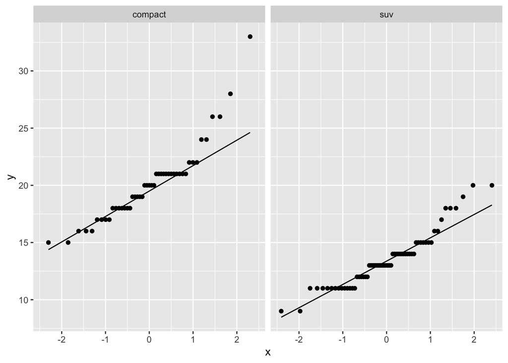

```r
ggplot(compact_suv, aes(sample = cty)) +
  geom_qq() +
  geom_qq_line() +
  facet_wrap(~ class)
```

use ‘pull()’ to create a vector from a df. t.test() uses vetors, not dfs.

```r
compact_sample <- compact_suv %>%
  filter(class == 'compact') %>%
  pull(cty)

suv_sample <- compact_suv %>%
  filter(class == 'suv') %>%
  pull(cty)
```

```r
t.test(compact_sample, suv_sample)
```

```
##
##  Welch Two Sample t-test
##
## data:  compact_sample and suv_sample
## t = 11.393, df = 79.558, p-value < 2.2e-16
## alternative hypothesis: true difference in means is not equal to 0
## 95 percent confidence interval:
##  5.469914 7.785405
## sample estimates:
## mean of x mean of y
##  20.12766  13.50000
```

There is a significant difference in mean city gas mileage between compact and SUV cars